# VS2.1 - Illustration of PCDs in One Triangle

Elvan Ceyhan

2023-12-18

First we load the `pcds` package:

```r
library(pcds)
```

# 1 Functions for Construction and Simulation of PCDs and Related Quantities

For illustration of construction of PCDs and related quantities, we first focus on one Delaunay cell, because subdigraph of the PCDs with vertices in one Delaunay cell are disconnected from the remaining vertices. Thus arc density and domination number of PCDs can be obtained by adding numbers of arcs and domination numbers for the subdigraphs for Delaunay cells. A Delaunay cell is an interval for 1D space, a triangle for 2D space, and a tetrahedron for 3D space. The arc density and the domination number of PE- and CS-PCDs for uniform data in two or higher dimensions, is geometry invariant, thus we may also focus on standard equilateral triangle in 2D space and a standard regular tetrahedron in the 3D space. *Geometry invariance* means that the distribution of arc density or domination number of these PCDs does not depend on the form (lengths of edges and inner angles) of the triangle or (lengths of edges, areas of faces and inner angles) of the tetrahedron for uniform data. So, one can use the standard Delaunay cells for computations and also simulations to utilize symmetry as the results extend to any type of Delaunay cell for uniform data. For one dimensional uniform data, the PCDs enjoy *scale invariance*, which means that the distribution of arc density and domination number does not depend on the length of the interval support. Thus, we present functions for a single Delaunay cell (and also for the standard Delaunay cells) in “Section VS2*” files.

# 2 Functions for PCDs with Vertices in One Triangle

Due to geometry invariance of PE- and CS-PCDs for uniform data (which will be the vertices of the PCDs) in any triangle in 2D space, most computations (and if needed data generation and simulations) can be done in the standard equilateral triangle, and for AS-PCD, one can restrict attention to the standard basic triangle. The *standard equilateral triangle* is $T_e=T(A,B,C)$ with vertices $A=(0,0)$, $B=(1,0)$, and $C=(1/2,\sqrt{3}/2)$ and the *standard basic triangle* is $T_b=T(A,B,C')$ with vertices $A=(0,0)$, $B=(1,0)$, and $C'=(c_1,c_2))$ with $0 < c_1 \le 1/2$, $c_2>0$, and $(1-c_1)^2+c_2^2 \le 1$.

For more detail on the construction and appealing properties of PCDs in triangles, see Ceyhan (2010) and Ceyhan (2012).

We first choose an arbitrary triangle $T=T(A,B,C)$ with vertices $A=(1,1)$, $B=(2,0)$, and $C=(1.5,2)$, which happens to be an obtuse triangle, and choose an arbitrary point in the interior of this triangle as the center (to construct the vertex or edge regions).

```r
A<-c(1,1); B<-c(2,0); C<-c(1.5,2);
Tr<-rbind(A,B,C);
n<-5

set.seed(1)
Xp<-runif.tri(n,Tr)$g  #try also Xp<-cbind(runif(n,1,2),runif(n,0,2))
M<-c(1.6,1.2) #try also M<-as.numeric(runif.tri(1,Tr)$g) or M="CC"
```

Then we generate $n=$ 5 $\mathcal{X}$ points inside the triangle $T$ using the function `runif.tri` in `pcds`. $\mathcal{X}$ points are denoted as `Xp` and $\mathcal{Y}$ points in Section “VS1_1_2DArtiData” correspond to the vertices of the triangle $T$. Hence, if the argument `Yp` is used for a function for multiple triangles, it is replaced with `tri` a $3 \times 2$ matrix in which rows represent the vertices of the triangle for a function written for a general triangle, with `c1,c2` for a basic triangle, or omitted for the standard equilateral triangle.

We plot the triangle $T$ and the $\mathcal{X}$ points in it using the below code, and also add the vertex names using the `text` function from base `R`.

```r
Xlim<-range(Tr[,1])
Ylim<-range(Tr[,2])
plot(Tr,pch=".",xlab="",ylab="",xlim=Xlim,ylim=Ylim+c(0,.1),main="Points in One Triangle")
polygon(Tr)
points(Xp)

#add the vertex names and annotation
txt<-rbind(Tr)
xc<-txt[,1]+c(-.01,.015,.02)
yc<-txt[,2]+c(.02,.02,.02)
txt.str<-c("A","B","C")
text(xc,yc,txt.str)
```

Alternatively, we can use the `plotDelaunay.tri` function in `pcds` to obtain the same plot by executing `plotDelaunay.tri(Xp,Tr,xlab="x",ylab="y")`.

## 2.1 Functions for Arc-Slice PCDs with Vertices in One Triangle

Arc-Slice (AS) proximity region for a point is the intersection of the triangle containing the point and the circle centered the point with radius being the minimum distance from the point to the vertices of the triangle. So, we first check whether a point is inside a circle or not by using the function `in.circle` which returns `TRUE` if the point is inside the circle, and `FALSE` otherwise. This function takes arguments `p,cent,rad,boundary` where

- `p` is a 2D point to be checked whether it is inside the circle or not,
- `cent` a 2D point in Cartesian coordinates which serves as the center of the circle,
- `rad` a positive real number which serves as the radius of the circle,
- `boundary` a logical parameter (default=`TRUE`) to include boundary or not, so if it is `TRUE`, the function checks if the point, `p`, lies in the closure of the circle (i.e., interior and boundary combined); else, it checks if `p` lies in the interior of the circle.

```r
cent<-c(1,1); rad<-1; p<-c(1.4,1.2) #try also cent<-runif(2); rad<-runif(1); p<-runif(2);
in.circle(p,cent,rad)
p<-c(.4,-.2)
in.circle(p,cent,rad)
```

```
#> [1] TRUE
#> [1] FALSE
```

The circle for an AS proximity region of an $\mathcal{X}$ point $x$ is centered at the point $x$ with radius being the distance from $x$ to the closest class $\mathcal{Y}$ point (which is the closest vertex of the triangle $T$ in the one triangle setting). The radius of a point from one class with respect to points from the other class is provided by the function `radius` which takes arguments `p,Y` where

- `p` is the point to find the radius for and
- `Y` is the matrix of non-target points.

The function also returns the index and coordinates of the class $\mathcal{Y}$ point closest to the class $\mathcal{X}$ point. This function works for points in other dimensions as well. See `? radius` for further description.

```r
ny<-5
Y<-cbind(runif(ny),runif(ny))
A<-c(1,1);
radius(A,Y)
```

```
#> $rad
#> [1] 0.3767951
#>
#> $index.of.clYpnt
#> [1] 4
#>
#> $closest.Ypnt
#> [1] 0.6684667 0.8209463
```

The radii of points from one class with respect to points from the other class are found by using the function `radii` which takes arguments `x,y` where

- `x` is a set of $d$-dimensional points for which the radii are computed. Radius of an `x` point equals to the distance to the closest `y` point and
- `y` is a set of $d$-dimensional points representing the reference points for the balls. That is, radius of an `x` point is defined as the minimum distance to the `y` points.

In addition to the radii, the function also returns the indices and coordinates of the class $\mathcal{Y}$ points closest to the class $\mathcal{X}$ points. This function works for points in other dimensions as well. See `? radii` for further description.

```r
nx<-6
ny<-5
X<-cbind(runif(nx),runif(nx))
Y<-cbind(runif(ny),runif(ny))
Rad<-radii(X,Y)
Rad
```

```
#> $radiuses
#> [1] 0.38015546 0.23618472 0.02161322 0.48477828 0.05674010 0.16819521
#>
#> $indices.of.closest.points
#> [1] 4 4 4 4 1 3
#>
#> $closest.points
#>            [,1]      [,2]
#> [1,] 0.51863426 0.4590657
#> [2,] 0.51863426 0.4590657
#> [3,] 0.51863426 0.4590657
#> [4,] 0.51863426 0.4590657
#> [5,] 0.07067905 0.4068302
#> [6,] 0.31627171 0.2936034
```

The function `NAStri` is used for the construction of AS proximity regions taking the arguments

- `p` the point for which the AS proximity region is to be found,
- `tri` the support triangle,
- `M` is the center to construct the vertex regions with default`M="CC"` (i.e. the circumcenter),
- `rv` the index of the vertex regions that the point `p` resides in with default `rv=NULL` and `dec` a positive integer the number of decimals (default is 4) to round the barycentric coordinates when checking whether the end points fall on the boundary of the triangle `tri` or not.

`NAStri` returns the proximity region as end points of the straight line segments on the boundary of the proximity region (which also fall on the boundary of the triangle), the end points of the arc slices which are the parts of the defining circle falling in the interior of the triangle and the angles between the vectors joining `P` and the end points of the arc slices and the horizontal line crossing the point `P`. It is also possible to specify the index of the vertex region for the point `P` with the argument `rv=k` for $k=1,2,3$, where $k$ refers to the vertex in $k$-th row for the triangle `Tr` (but this must be computed before such as in the code `Rv<-rel.vert.triCC(P1,Tr)$rv; NAStri(P1,Tr,M,Rv)` and it must be compatible with the vertex region for the point `P`).

```r
P<-c(1.8,.5)
NAStri(P,Tr,M)
```

```
#> $L
#>      [,1] [,2]
#> [1,]    2    0
#> [2,]    2    0
#>
#> $R
#>          [,1]     [,2]
#> [1,] 1.741176 1.035294
#> [2,] 1.300000 0.700000
#>
#> $arc.slices
#>          [,1]     [,2]
#> [1,] 1.741176 1.035294
#> [2,] 1.300000 0.700000
#>
#> $Angles
#> [1] 1.680247 2.761086
```

Indicator for the presence of an arc from a (data or $\mathcal{X}$) point to another for AS-PCDs is the function `IarcAStri`. One can use it for points in the data set or for arbitrary points (as if they were in the data set). It takes the arguments,

- `p1` a 2D point whose AS proximity region is constructed,
- `p2` another 2D point. The function determines whether `p2` is inside the AS proximity region of `p1` or not,
- `tri` vertices of the support triangle, stacked row-wise, i.e., each row representing a vertex of the triangle,
- `M` the center of the triangle to construct the vertex regions with, default is `M="CC"` i.e., the circumcenter of `tri` and `rv` the index of the `M`-vertex region in `tri` containing the point, either 1,2,3 or `NULL` (which is the default).

This function returns $I(p2 \in N_{AS}(p1))$, that is, returns 1 if `p2` is in $N_{AS}(p1)$, 0 otherwise.

```r
#between two arbitrary points P1 and P2
P1<-as.numeric(runif.tri(1,Tr)$g)
P2<-as.numeric(runif.tri(1,Tr)$g)
IarcAStri(P1,P2,Tr,M)
```

```
#> [1] 0
```

```r
#between the first two points in Xp
IarcAStri(Xp[1,],Xp[2,],Tr,M)
```

```
#> [1] 0
```

AS proximity regions are defined with respect to the vertices of the triangle (i.e., with respect to the vertex regions they reside in) and vertex regions in each triangle are based on the center `M` for circumcenter or $M=(\alpha,\beta,\gamma)$ in barycentric coordinates in the interior of the triangle; default is `M="CC"` i.e., circumcenter of the triangle.

See Ceyhan (2005), Ceyhan (2010), and Ceyhan (2012) for more on AS-PCDs.

Number of arcs of the AS-PCD can be computed by the function `num.arcsAStri`. The function `num.arcsAStri` is an object of class “`NumArcs`” and takes `Xp,tri,M="CC"` as its arguments where `Xp` is the data set, and the others are as above and returns the list of

- `desc`: A description of the PCD and the output
- `num.arcs`: Number of arcs of the AS-PCD,
- `num.in.tri`: Number of `Xp` points in the triangle `tri`,
- `ind.in.tri`: The vector of indices of the `Xp` points that reside in the triangle.
- `tess.points`: vertices of the support triangle (i.e. `Yp` points)
- `vertices`: vertices of the PCD (i.e. `Xp` points)

```r
Narcs = num.arcsAStri(Xp,Tr)  #with default M="CC"; try also num.arcsAStri(Xp,Tr,M)
summary(Narcs)
```

```
#> Call:
#> num.arcsAStri(Xp = Xp, tri = Tr)
#>
#> Description of the output:
#> Number of Arcs of the AS-PCD and the Related Quantities with vertices Xp in One Triangle
#>
#> Number of data (Xp) points in the triangle =  5
#> Number of arcs in the digraph =  10
#>
#> Indices of data points in the triangle:
#> 1 2 3 4 5
#>
```

```r
#plot(Narcs)
```

The arc density of the AS-PCD can be computed by the function `ASarc.dens.tri`. It takes the arguments `Xp,tri,M="CC",in.tri.only` where `Xp` is the data set (or $\mathcal{X}$ points) `tri,M="CC"` are as above. `in.tri.only` is a logical argument (default is `FALSE`) for considering only the points inside the triangle or all the points as the vertices of the digraph. if `in.tri.only=TRUE`, arc density is computed only for the points inside the triangle (i.e., arc density of the subdigraph induced by the vertices in the triangle is computed), otherwise arc density of the entire digraph (i.e., digraph with all the vertices) is computed.

```r
ASarc.dens.tri(Xp,Tr,M)
```

```
#> [1] 0.5
```

The incidence matrix of the AS-PCD for the one triangle case can be found by `inci.matAStri`, using the `inci.matAStri(Xp,Tr,M)` command. It takes the same arguments as the function `num.arcsAStri`.

Plot of the arcs in the digraph AS-PCD, which is based on the $M$-vertex regions with $M=($ 1.6,1.2 $)$, can be obtained by the function `plotASarcs.tri`, which is the one-tri counterpart of the function `plotASarcs`. It takes arguments `Xp,tri,M="CC"` (as in `num.arcsAStri`) and other options for the plot function. See the help page for the function using `? plotASarcs.tri`.

Plot of the arcs of the above AS-PCD, together with the vertex regions (with the option `vert.reg = TRUE`).

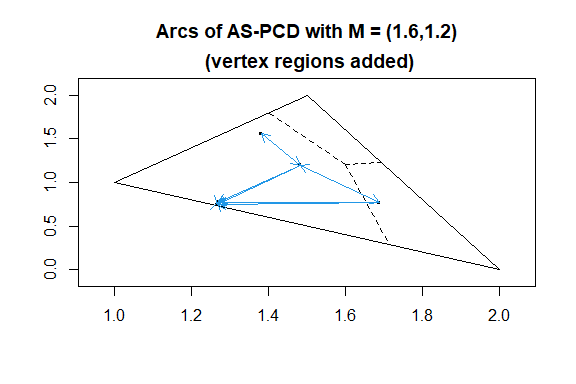

```r
plotASarcs.tri(Xp,Tr,M,xlab="",ylab="",vert.reg = TRUE)
```

Or, one can use the default center `M="CC"`, and can add vertex names and text to the figure (with vertex regions) using the below code. The part `M = as.numeric(arcsAStri(Xp,Tr)$param)` is optional, for the below annotation of the plot since circumcenter is used for the vertex regions.

```r
oldpar <- par(pty = "s")
plotASarcs.tri(Xp,Tr,asp=1,xlab="",ylab="",vert.reg = TRUE); M = (arcsAStri(Xp,Tr)$param)$c

CC<-circumcenter.tri(Tr)

#determine whether the center used for vertex regions is circumcenter or not
if (identical(M,CC) || identical(M,"CC"))
{cent<-CC
D1<-(B+C)/2; D2<-(A+C)/2; D3<-(A+B)/2;
Ds<-rbind(D1,D2,D3)
cent.name<-"CC"
} else
{cent<-M
cent.name<-"M"
Ds<-prj.cent2edges(Tr,M)
}

#add the vertex names and annotation
txt<-rbind(Tr,cent,Ds)
xc<-txt[,1]+c(-.02,.02,.02,.05,.05,-0.03,-.01)
yc<-txt[,2]+c(.02,.02,.02,.07,.02,.05,-.06)
txt.str<-c("A","B","C",cent.name,"D1","D2","D3")
text(xc,yc,txt.str)
par(oldpar)
```

Plot of the AS proximity regions can be obtained by the function `plotASregs.tri`. It takes arguments `Xp,tri,M="CC"` (as in `num.arcsAStri`) and other options for the plot function. See the help page for the function using `? plotASregs.tri`.

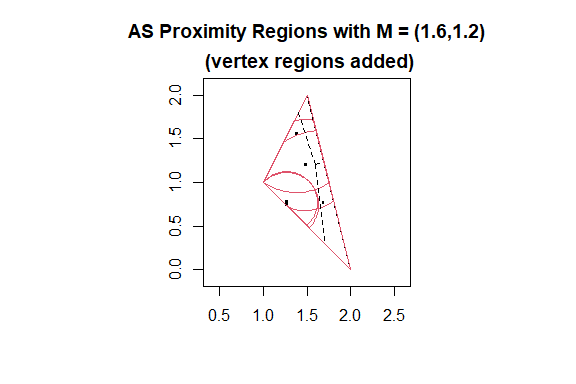

Figure 2.2: AS proximity regions for the $X$ points used above.

```r
M<-c(1.6,1.2) #try also M<-c(1.6620051,0.8136604) or M="CC"
oldpar <- par(pty = "s")
plotASregs.tri(Xp,Tr,M,vert.reg = T,xlab="",ylab="")
```

```r
par(oldpar)
```

The function `arcsAStri` is an object of class “`PCDs`”. It takes arguments `Xp,tri,M="CC"` (as in `ASarc.dens.tri`). The output list is as in the function `arcsAS` (see Section “VS1_1_2DArtiData”). The `plot` function returns the same plot as in `plotASarcs.tri` with $M=($ 1.6,1.2 $)$, hence we comment it out below.

```r
M=c(1.6,1.2) #try also M=c(1.6620051,0.8136604)

Arcs<-arcsAStri(Xp,Tr,M) #try also Arcs<-arcsAStri(Xp,Tr) #uses the default center, namely circumcenter for M
Arcs
```

```
#> Call:
#> arcsAStri(Xp = Xp, tri = Tr, M = M)
#>
#> Type:
#> [1] "Arc Slice Proximity Catch Digraph (AS-PCD) for 2D Points in the Triangle with Center M = (1.6,1.2)"
```

```r
summary(Arcs)
```

```
#> Call:
#> arcsAStri(Xp = Xp, tri = Tr, M = M)
#>
#> Type of the digraph:
#> [1] "Arc Slice Proximity Catch Digraph (AS-PCD) for 2D Points in the Triangle with Center M = (1.6,1.2)"
#>
#>  Vertices of the digraph =  Xp
#>  Partition points of the region =  Tr
#>
#>  Selected tail (or source) points of the arcs in the digraph
#>       (first 6 or fewer are printed)
#>          [,1]      [,2]
#> [1,] 1.265509 0.7442478
#> [2,] 1.687023 0.7682074
#> [3,] 1.687023 0.7682074
#> [4,] 1.687023 0.7682074
#> [5,] 1.380035 1.5548904
#> [6,] 1.267221 0.7722282
#>
#>  Selected head (or end) points of the arcs in the digraph
#>       (first 6 or fewer are printed)
#>          [,1]      [,2]
#> [1,] 1.267221 0.7722282
#> [2,] 1.265509 0.7442478
#> [3,] 1.267221 0.7722282
#> [4,] 1.482080 1.1991317
#> [5,] 1.482080 1.1991317
#> [6,] 1.265509 0.7442478
#>
#> Parameters of the digraph
#> $center
#> [1] 1.6 1.2
#>
#> Various quantities of the digraph
#>         number of vertices number of partition points
#>                        5.0                        3.0
#>        number of triangles             number of arcs
#>                        1.0                       10.0
#>                arc density
#>                        0.5
```

```r
plot(Arcs)
```

To see the code and the plot for the arcs using the `plot.PCDs` function, with vertex names and annotation added to the plot, type `? arcsAStri`.

## 2.2 Functions for Proportional Edge PCDs with Vertices in One Triangle

In this section, we use the same triangle $T$ and generate data as in Section 2.1.

```r
#A<-c(1,1); B<-c(2,0); C<-c(1.5,2); Tr<-rbind(A,B,C); n<-5
#set.seed(1); Xp<-runif.tri(n,Tr)$g
M<-c(1.6,1.0)  #try also M<-as.numeric(runif.tri(1,Tr)$g)
r<-1.5  #try also r<-2
```

And choose the expansion parameter $r=$ 1.5 to illustrate proportional edge (PE) proximity regions and the associated PCDs.

The function `NPEtri` is used for the construction of PE proximity regions taking the arguments `p,tri,r,M=c(1,1,1),rv=NULL` where

- `p,tri,rv=NULL` are as in the function `NAStri`, and
- `M` is the center to construct the vertex regions with default `M=c(1,1,1)` (i.e. the center of mass),
- `rv` the index of the vertex regions that the point `p` resides in with default `rv=NULL` and
- `r` is the expansion parameter (must be $\ge 1$).

`NPEtri` returns the PE proximity region (i.e., the vertices of the triangular proximity region).

```r
P<-c(1.8,.5)
NPEtri(P,Tr,r,M)
```

```
#>       [,1] [,2]
#> [1,] 2.000 0.00
#> [2,] 1.550 0.45
#> [3,] 1.775 0.90
```

Indicator for the presence of an arc from a (data or $\mathcal{X}$) point to another for PE-PCDs is the function `IarcPEtri`. One can use it for points in the data set or for arbitrary points (as if they were in the data set). It takes the arguments, `p1,p2,tri,r,M=c(1,1,1),rv=NULL` where

-`p1,p2,tri,rv=NULL` are as in `IarcAStri` and - `r,M=c(1,1,1)` are as in `NPEtri`.

This function returns $I(p2 \in N_{PE}(p1))$, that is, returns 1 if `p2` is in $N_{PE}(p1)$, 0 otherwise.

```r
P1<-as.numeric(runif.tri(1,Tr)$g)
P2<-as.numeric(runif.tri(1,Tr)$g)
IarcPEtri(P1,P2,Tr,r,M)
```

```
#> [1] 1
```

```r
IarcPEtri(Xp[1,],Xp[5,],Tr,r,M) #try also IarcPEtri(Xp[5,],Xp[1,],Tr,r,M)
```

```
#> [1] 0
```

Number of arcs of the PE-PCD can be computed by the function `num.arcsPEtri`, which is an object of class “`NumArcs`” and takes arguments `Xp,tri,r,M=c(1,1,1)` where `Xp` is the data set, and the others are as above. The output is as in `num.arcsAStri`.

```r
Narcs = num.arcsPEtri(Xp,Tr,r,M)
summary(Narcs)
```

```
#> Call:
#> num.arcsPEtri(Xp = Xp, tri = Tr, r = r, M = M)
#>
#> Description of the output:
#> Number of Arcs of the PE-PCD with vertices Xp and Quantities Related to the Support Triangle
#>
#> Number of data (Xp) points in the triangle =  5
#> Number of arcs in the digraph =  7
#>
#> Indices of data points in the triangle:
#> 1 2 3 4 5
#>
```

```r
#plot(Narcs)
```

The arc density of the PE-PCD can be computed by the function `PEarc.dens.tri`. It takes the arguments `Xp,tri,r,M,in.tri.only` where `Xp` is the data set (or $\mathcal{X}$ points) `r,tri,M` are as above, `in.tri.only` is as in `ASarc.dens.tri`, and returns output as list with elements

- `arc.dens`, arc density of PE-PCD whose vertices are the 2D numerical data set, `Xp`,
- `std.arc.dens`, the arc density standardized by the mean and asymptotic variance of the arc density of PE-PCD for uniform data in the triangle `tri`, and
- `caveat` a warning as `"The standardized arc density is only correct when M is the center of mass in the current version"`.

The standardized arc density is only correct when $M$ is the center of mass in the current version.

```r
PEarc.dens.tri(Xp,Tr,r,M)
```

```
#> $arc.dens
#> [1] 0.35
```

The incidence matrix of the PE-PCD for the one triangle case can be found by the function `inci.matPEtri`, using e.g. the `inci.matPEtri(Xp,Tr,r,M)` command. It takes the same arguments as the function `num.arcsPEtri`.

Plot of the arcs in the digraph PE-PCD, which is based on the $M$-vertex regions with $M=$(1.6,1), can be obtained by the function `plotPEarcs.tri`, which is the one-tri counterpart of the function `plotPEarcs`. It takes arguments `Xp,tri,r,M=c(1,1,1)` (as in `num.arcsPEtri`) and other options for the plot function. See the help page for the function using `? plotPEarcs.tri`.

Plot of the arcs of the above PE-PCD, together with the vertex regions (with the option `vert.reg = TRUE`) and vertex names added to the figure.

```r
plotPEarcs.tri(Xp,Tr,r,M,xlab="",ylab="",vert.reg = TRUE)
#add vertex labels and text to the figure (with vertex regions)
ifelse(isTRUE(all.equal(M,circumcenter.tri(Tr))),
       {Ds<-rbind((B+C)/2,(A+C)/2,(A+B)/2); cent.name="CC"},{Ds<-prj.cent2edges(Tr,M); cent.name="M"})
```

```
#> [1] "M"
```

```r
txt<-rbind(Tr,M,Ds)
xc<-txt[,1]+c(-.02,.02,.02,.02,.04,-0.03,-.01)
yc<-txt[,2]+c(.02,.02,.02,.05,.02,.04,-.06)
txt.str<-c("A","B","C",cent.name,"D1","D2","D3")
text(xc,yc,txt.str)
```

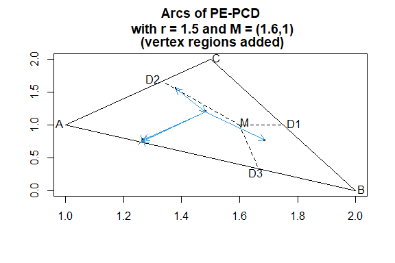

Plots of the PE proximity regions can be obtained by the function `plotPEregs.tri`. It takes arguments `Xp,tri,r,M=c(1,1,1)` (as in `num.arcsPEtri`) and other options for the plot function. See the help page for the function using `? plotPEregs.tri`.

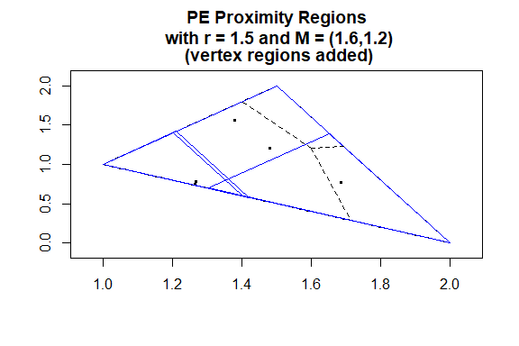

Figure 2.4: PE proximity regions for the $X$ points used above.

```r
M<-c(1.6,1.2) #try also M<-c(1.6620051,0.8136604) or M="CC"
plotPEregs.tri(Xp,Tr,r,M,vert.reg = T,xlab="",ylab="")
```

The function `ArcsPEtri` is an object of class “`PCDs`”. It takes arguments `Xp,tri,r,M=c(1,1,1)` (as in `num.arcsPEtri`). The output list is as in the `arcsAStri` except the parameters of the digraph (center for PE-PCD and the expansion parameter). The `plot` function returns the same plot as in `plotPEarcs.tri`, hence we comment it out below.

```r
Arcs<-ArcsPEtri(Xp,Tr,r,M) #or try with the default center Arcs<-ArcsPEtri(Xp,Tr,r); M= (Arcs$param)$cent
Arcs
```

```
#> Call:
#> ArcsPEtri(Xp = Xp, tri = Tr, r = r, M = M)
#>
#> Type:
#> [1] "Proportional Edge Proximity Catch Digraph (PE-PCD) for 2D Points in the Triangle with Expansion Parameter r = 1.5 and Center M = (1.6,1.2)"
```

```r
summary(Arcs)
```

```
#> Call:
#> ArcsPEtri(Xp = Xp, tri = Tr, r = r, M = M)
#>
#> Type of the digraph:
#> [1] "Proportional Edge Proximity Catch Digraph (PE-PCD) for 2D Points in the Triangle with Expansion Parameter r = 1.5 and Center M = (1.6,1.2)"
#>
#>  Vertices of the digraph =  Xp
#>  Partition points of the region =  Tr
#>
#>  Selected tail (or source) points of the arcs in the digraph
#>       (first 6 or fewer are printed)
#>          [,1]      [,2]
#> [1,] 1.265509 0.7442478
#> [2,] 1.380035 1.5548904
#> [3,] 1.380035 1.5548904
#> [4,] 1.380035 1.5548904
#> [5,] 1.380035 1.5548904
#> [6,] 1.267221 0.7722282
#>
#>  Selected head (or end) points of the arcs in the digraph
#>       (first 6 or fewer are printed)
#>          [,1]      [,2]
#> [1,] 1.267221 0.7722282
#> [2,] 1.265509 0.7442478
#> [3,] 1.687023 0.7682074
#> [4,] 1.267221 0.7722282
#> [5,] 1.482080 1.1991317
#> [6,] 1.265509 0.7442478
#>
#> Parameters of the digraph
#> $center
#> [1] 1.6 1.2
#>
#> $`expansion parameter`
#> [1] 1.5
#>
#> Various quantities of the digraph
#>         number of vertices number of partition points
#>                        5.0                        3.0
#>        number of triangles             number of arcs
#>                        1.0                       10.0
#>                arc density
#>                        0.5
```

```r
plot(Arcs)
```

To see the code and the plot for the arcs using the `plot.PCDs` function, with vertex names and annotation added to the plot, type `? ArcsPEtri`.

## 2.3 Functions for Central Similarity PCDs with Vertices in One Triangle

We use the same triangle $T$ and generated data as Section 2.2.

```r
tau<-1.5
```

And choose the expansion parameter $\tau=$ 1.5 to illustrate central similarity proximity regions and the associated PCDs.

The function `NCStri` is used for the construction of CS proximity regions taking the arguments `p,tri,t,M=c(1,1,1),re=NULL` where

- `p,tri,M=c(1,1,1)` are as in the function `NPEtri`, and
- `re` the index of the edge regions that the point `p` resides in with default `re=NULL` and
- `t` is the expansion parameter (must be $> 0$).

`NCStri` returns the CS proximity region (i.e., the vertices of the triangular proximity region).

```r
P<-c(1.8,.5)
NCStri(P,Tr,tau,M)
```

```
#>         [,1]   [,2]
#> [1,] 1.74375 0.9500
#> [2,] 1.51250 0.4875
#> [3,] 1.97500 0.0250
```

Indicator for the presence of an arc from a (data or $\mathcal{X}$) point to another for CS-PCDs is the function `IarcCStri`. One can use it for points in the data set or for arbitrary points (as if they were in the data set). It takes the arguments, `p1,p2,tri,t,M,re=NULL` where `p1,p2,tri,M` are as in `IarcPEtri` and `t,re=NULL` are as in `NCStri`. This function returns $I(p2 \in N_{CS}(p1))$, that is, returns 1 if `p2` is in $N_{CS}(p1)$, 0 otherwise.

```r
P1<-as.numeric(runif.tri(1,Tr)$g)
P2<-as.numeric(runif.tri(1,Tr)$g)
IarcCStri(P1,P2,Tr,tau,M)
```

```
#> [1] 1
```

```r
IarcCStri(Xp[1,],Xp[2,],Tr,tau,M)
```

```
#> [1] 0
```

Number of arcs of the CS-PCD can be computed by the function `num.arcsCStri`. The output is as in `num.arcsPEtri`.

Number of arcs of the CS-PCD can be computed by the function `num.arcsCStri`, which is an object of class “`NumArcs`” and takes arguments `Xp,tri,t,M=c(1,1,1)` where `Xp` is the data set, and the others are as above. The output is as in `num.arcsPEtri`.

```r
Narcs = num.arcsCStri(Xp,Tr,t=.5,M)
summary(Narcs)
```

```
#> Call:
#> num.arcsCStri(Xp = Xp, tri = Tr, t = 0.5, M = M)
#>
#> Description of the output:
#> Number of Arcs of the CS-PCD with vertices Xp and Quantities Related to the Support Triangle
#>
#> Number of data (Xp) points in the triangle =  5
#> Number of arcs in the digraph =  0
#>
#> Indices of data points in the triangle:
#> 1 2 3 4 5
#>
```

```r
#plot(Narcs)
```

The arc density of the CS-PCD can be computed by the function `CSarc.dens.tri`. It takes the arguments `Xp,tri,t,M=c(1,1,1),in.tri.only=FALSE` where `Xp` is the data set (or $\mathcal{X}$ points) `tri,t,M=c(1,1,1),in.tri.only=FALSE` are as above and `in.tri.only` is as in `ASarc.dens.tri`.

```r
CSarc.dens.tri(Xp,Tr,tau,M)
```

[output not shown]

The incidence matrix of the CS-PCD for the one triangle case can be found by `inci.matCStri`, using the `inci.matCStri(Xp,Tr,tau,M)` command. It takes the same arguments as the function `num.arcsCStri`.

Plot of the arcs in the digraph CS-PCD, which is based on the $M$-edge regions with $M=$(1.6,1.2). can be obtained by the function `plotCSarcs.tri`, which is the one-tri counterpart of the function `plotCSarcs`. It takes arguments `Xp,tri,t,M=c(1,1,1)` (as in `num.arcsPEtri`) and other options for the plot function. See the help page for the function using `? plotCSarcs.tri`.

Plot of the arcs of the above CS-PCD, together with the edge regions (with the option `edge.reg = TRUE`) and vertex names added to the figure.

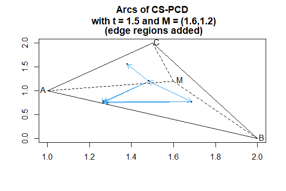

```r
t<-1.5  #try also t<-2
plotCSarcs.tri(Xp,Tr,t,M,xlab="",ylab="",edge.reg = TRUE)
txt<-rbind(Tr,M)
xc<-txt[,1]+c(-.02,.02,.02,.03)
yc<-txt[,2]+c(.02,.02,.02,.03)
txt.str<-c("A","B","C","M")
text(xc,yc,txt.str)
```

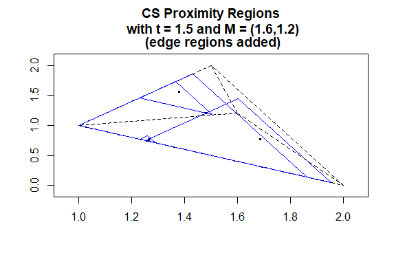

Figure 2.6: CS proximity regions for the $X$ points used above.

```r
plotCSregs.tri(Xp,Tr,t,M,edge.reg=T,xlab="",ylab="")
```

The function `arcsCStri` is an object of class “`PCDs`”. It takes arguments `Xp,tri,t,M=c(1,1,1)` (as in `num.arcsCStri`). The output list is as in the `ArcsPEtri`. The `plot` function returns the same plot as in `plotCSarcs.tri`, hence we comment it out below.

```r
Arcs<-arcsCStri(Xp,Tr,t,M)
Arcs
```

```
#> Call:
#> arcsCStri(Xp = Xp, tri = Tr, t = t, M = M)
#>
#> Type:
#> [1] "Central Similarity Proximity Catch Digraph (CS-PCD) for 2D Points in the Triangle with Expansion Parameter t = 1.5 and Center M = (1.6,1.2)"
```

```r
summary(Arcs)
```

```
#> Call:
#> arcsCStri(Xp = Xp, tri = Tr, t = t, M = M)
#>
#> Type of the digraph:
#> [1] "Central Similarity Proximity Catch Digraph (CS-PCD) for 2D Points in the Triangle with Expansion Parameter t = 1.5 and Center M = (1.6,1.2)"
#>
#>  Vertices of the digraph =  Xp
#>  Partition points of the region =  Tr
#>
#>  Selected tail (or source) points of the arcs in the digraph
#>       (first 6 or fewer are printed)
#>          [,1]      [,2]
#> [1,] 1.687023 0.7682074
#> [2,] 1.687023 0.7682074
#> [3,] 1.687023 0.7682074
#> [4,] 1.267221 0.7722282
#> [5,] 1.482080 1.1991317
#> [6,] 1.482080 1.1991317
#>
#>  Selected head (or end) points of the arcs in the digraph
#>       (first 6 or fewer are printed)
#>          [,1]      [,2]
#> [1,] 1.265509 0.7442478
#> [2,] 1.267221 0.7722282
#> [3,] 1.482080 1.1991317
#> [4,] 1.265509 0.7442478
#> [5,] 1.265509 0.7442478
#> [6,] 1.687023 0.7682074
#>
#> Parameters of the digraph
#> $center
#> [1] 1.6 1.2
#>
#> $`expansion parameter`
#> [1] 1.5
#>
#> Various quantities of the digraph
#>         number of vertices number of partition points
#>                        5.0                        3.0
#>        number of triangles             number of arcs
#>                        1.0                        8.0
#>                arc density
#>                        0.4
```

```r
plot(Arcs)
```

To see the code and the plot for the arcs using the `plot.PCDs` function, with vertex names and annotation added to the plot, type `? arcsCStri`.

## 2.4 Functions for Proportional Edge PCDs with Vertices in the Standard Equilateral Triangle

We first define the standard equilateral triangle $T_e=T(A,B,C)$ with vertices $A=(0,0)$, $B=(1,0)$, and $C=(1/2,\sqrt{3}/2)$.

```r
A<-c(0,0); B<-c(1,0); C<-c(1/2,sqrt(3)/2);
Te<-rbind(A,B,C);
n<-5  #try also n<-10, 50, or 100
set.seed(1)
Xp<-runif.std.tri(n)$gen.points
M<-c(.6,.2)  #try also M<-c(1,1,1)
```

Plot of the triangle $T_e$ and the $\mathcal{X}$ points in it can be obtained by the below code, and we also add the vertex names and annotation using the `text` function from base `R`. We use `asp=1` in the below plot so that the standard equilateral triangle is plotted with equal length edges.

```r
Xlim<-range(Te[,1])
Ylim<-range(Te[,2])
plot(Te,asp=1,pch=".",xlab="",ylab="",xlim=Xlim,ylim=Ylim,main="Points in Standard Equilateral Triangle")
polygon(Te)
points(Xp)

#add the vertex names and annotation
txt<-rbind(Te)
xc<-txt[,1]+c(-.02,.02,.02)
yc<-txt[,2]+c(.01,.01,.01)
txt.str<-c("A","B","C")
text(xc,yc,txt.str)
```

Alternatively, we can use the `plotDelaunay.tri` function in `pcds` to obtain the same plot by executing `plotDelaunay.tri(Xp,Te,xlab="x",ylab="y",main="Points in Standard Equilateral Triangle")` command.

Indicator for the presence of an arc from a (data or $\mathcal{X}$) point to another for PE-PCDs is the function `IarcPEstd.tri`. One can use it for points in the data set or for arbitrary points (as if they were in the data set). It takes the arguments, `p1,p2,r,M=c(1,1,1),rv=NULL` as in `IarcPEtri`.

```r
P1<-as.numeric(runif.tri(1,Te)$g)
P2<-as.numeric(runif.tri(1,Te)$g)
r=2
IarcPEstd.tri(P1,P2,r,M)
```

```
#> [1] 1
```

```r
IarcPEstd.tri(Xp[1,],Xp[2,],r,M)
```

```
#> [1] 1
```

Number of arcs of the PE-PCD can be computed by the function `num.arcsPEstd.tri`which which is an object of class “`NumArcs`” and takes arguments as the function `num.arcsPEtri`. The output is as in `num.arcsPEtri`.

```r
Narcs = num.arcsPEstd.tri(Xp,r=1.25,M)
summary(Narcs)
```

```
#> Call:
#> num.arcsPEstd.tri(Xp = Xp, r = 1.25, M = M)
#>
#> Description of the output:
#> Number of Arcs of the PE-PCD and the Related Quantities with vertices Xp in the Standard Equilateral Triangle
#>
#> Number of data (Xp) points in the triangle =  5
#> Number of arcs in the digraph =  5
#>
#> Indices of data points in the triangle:
#> 1 2 3 4 5
#>
```

```r
#plot(Narcs)
```

The incidence matrix of the PE-PCD for the one triangle case can be found by `inci.matPETe`, using the `inci.matPETe(Xp,r,M)` command.

## 2.5 Functions for Central Similarity PCDs with Vertices in the Standard Equilateral Triangle

We use the same setting for the data points and the center as in Section 2.4. Notice that the argument `tri` is redundant for the functions specific to the standard equilateral triangle, hence they are omitted for the functions which have counterparts in Section 2.3.

```r
P1<-as.numeric(runif.tri(1,Te)$g)
P2<-as.numeric(runif.tri(1,Te)$g)
tau=1
IarcCSstd.tri(P1,P1,tau,M)
IarcCSstd.tri(P1,P2,tau,M)
IarcCSstd.tri(Xp[1,],Xp[2,],tau,M)
```

[output not shown]

Number of arcs of the CS-PCD can be computed by the function `num.arcsCSstd.tri` which is an object of class “`NumArcs`” and its arguments and output are as in `num.arcsCStri`.

```r
set.seed(123)
M<-as.numeric(runif.std.tri(1)$g)  #try also M<-c(.6,.2)
Narcs = num.arcsCStri(Xp,Te,t=1.5,M)
summary(Narcs)
```

```
#> Call:
#> num.arcsCStri(Xp = Xp, tri = Te, t = 1.5, M = M)
#>
#> Description of the output:
#> Number of Arcs of the CS-PCD with vertices Xp and Quantities Related to the Support Triangle
#>
#> Number of data (Xp) points in the triangle =  5
#> Number of arcs in the digraph =  3
#>
#> Indices of data points in the triangle:
#> 1 2 3 4 5
#>
```

```r
#plot(Narcs)
```

The incidence matrix of the CS-PCD for the one triangle case can be found by `inci.matCSstd.tri`, using e.g. the `inci.matCSstd.tri(Xp,t=1.5,M)` command.

## 2.6 Auxiliary Functions to Define Proximity Regions for Points in a Triangle

The PCDs are constructed using proximity regions, and proximity region of an $\mathcal{X}$ point depends on its location relative to the $\mathcal{Y}$ points. In particular, AS- and PE-PCDs depend on the vertex regions and CS-PCDs depend on edge regions. We will illustrate the vertex and edge regions in this section. These regions partition the Delaunay cell (e.g., Delaunay triangle in $\mathbb R^2$) based on a center or central point in the triangle.

We first check whether a point is inside a triangle or not which can be done using the function `in.triangle`, which takes arguments `p,tri,boundary=FALSE` where

The function gives `TRUE` if the point is inside the triangle, and `FALSE` otherwise. It also returns the barycentric coordinates of the point with respect to the triangle.

```r
A<-c(1,1); B<-c(2,0); C<-c(1.5,2); p<-c(1.4,1.2)
Tr<-rbind(A,B,C)
in.triangle(p,Tr)
```

```
#> $in.tri
#> [1] TRUE
#>
#> $barycentric
#> [1] 0.4 0.2 0.4
```

We now illustrate *circumcenter* of a triangle. The function `circumcenter.tri` takes `tri` as its sole argument for a triangle and returns the circumcenter of the triangle as its output.

```r
A<-c(1,1); B<-c(2,0); C<-c(1.5,2);
Tr<-rbind(A,B,C);  #the vertices of the triangle Tr
(CC<-circumcenter.tri(Tr)) #the circumcenter
```

```
#> [1] 2.083333 1.083333
```

We plot the circumcenter of an obtuse triangle below (so circumcenter is outside of the triangle) using the below code, see also the help page with `? circumcenter.tri` for the code to generate this figure. Notice that in the code we used `asp=1` so that lines joining CC to the edges of the triangle appear perpendicular to the edges.

```r
D1<-(B+C)/2; D2<-(A+C)/2; D3<-(A+B)/2; #midpoints of the edges
Ds<-rbind(D1,D2,D3)

Xlim<-range(Tr[,1],CC[1])
Ylim<-range(Tr[,2],CC[2])
xd<-Xlim[2]-Xlim[1]
yd<-Ylim[2]-Ylim[1]

oldpar <- par(pty="s")
plot(A,asp=1,pch=".",xlab="",ylab="",
     main="Circumcenter of a Triangle",
     axes=TRUE,xlim=Xlim+xd*c(-.05,.05),ylim=Ylim+yd*c(-.05,.05))
polygon(Tr)
points(rbind(CC))
L<-matrix(rep(CC,3),ncol=2,byrow=TRUE); R<-Ds
segments(L[,1], L[,2], R[,1], R[,2], lty=2)

txt<-rbind(Tr,CC,Ds)
xc<-txt[,1]+c(-.08,.08,.08,.12,-.09,-.1,-.09)
yc<-txt[,2]+c(.02,-.02,.03,-.06,.02,.06,-.04)
txt.str<-c("A","B","C","CC","D1","D2","D3")
text(xc,yc,txt.str)
par(oldpar)
```

The function `circumcenter.basic.tri` is a special case of `circumcenter.tri` and takes the argument `c1,c2` and returns the circumcenter of the standard basic triangle.

The function `center.nondegPE` takes arguments `tri,r` which are the triangle and the expansion parameter for the PE proximity regions, respectively. It returns the three centers for non-degenerate asymptotic distribution of domination number of PE-PCDs for $r \in (1,1.5)$ and the center of mass for $r=1.5$. This center is not defined for $r > 1.5$, as the asymptotic distribution is degenerate in this case.

```r
A<-c(1,1); B<-c(2,0); C<-c(1.5,2);
Tr<-rbind(A,B,C);
r<-1.35
(Ms<-center.nondegPE(Tr,r))
```

```
#>        [,1]      [,2]
#> M1 1.388889 1.0000000
#> M2 1.611111 0.7777778
#> M3 1.500000 1.2222222
```

We plot the non-degeneracy centers for the triangle `Tr` using the below code, type also `? center.nondegPE` for the code to generate this figure.

```r
Xlim<-range(Tr[,1])
Ylim<-range(Tr[,2])
xd<-Xlim[2]-Xlim[1]
yd<-Ylim[2]-Ylim[1]

plot(Tr,pch=".",xlab="",ylab="",
     main="Centers of nondegeneracy of the domination number\n of the PE-PCD in a triangle",
     axes=TRUE,xlim=Xlim+xd*c(-.05,.05),ylim=Ylim+yd*c(-.05,.05))
polygon(Tr)
points(Ms,pch=".",col=1)
polygon(Ms,lty=2)

xc<-Tr[,1]+c(-.02,.02,.02)
yc<-Tr[,2]+c(.02,.02,.03)
txt.str<-c("A","B","C")
text(xc,yc,txt.str)

xc<-Ms[,1]+c(-.04,.04,.03)
yc<-Ms[,2]+c(.02,.02,.05)
txt.str<-c(expression(M[1]),"M2","M3")
text(xc,yc,txt.str)
```

The function `prj.cent2edges` returns the projections of a point (e.g., a center) $M$ inside a triangle to its edges, i.e., it returns the *intersection point* where the line joining a vertex to $M$ crosses the opposite edge. The line segments between $M$ the intersection points define the $M$-vertex regions.

```r
A<-c(1,1); B<-c(2,0); C<-c(1.5,2);
Tr<-rbind(A,B,C);
M<-c(1.6,1.0)  #try also M<-as.numeric(runif.tri(1,Tr)$g)
(Ds<-prj.cent2edges(Tr,M))  #try also prj.cent2edges(Tr,M=c(1,1))
```

```
#>          [,1]      [,2]
#> [1,] 1.750000 1.0000000
#> [2,] 1.333333 1.6666667
#> [3,] 1.666667 0.3333333
```

We plot the projections of center $M$ to the edges of the triangle `Tr` using the below code, type also `? prj.cent2edges` for the code to generate this figure.

```r
M<-c(1.6,1.0)
Xlim<-range(Tr[,1])
Ylim<-range(Tr[,2])
xd<-Xlim[2]-Xlim[1]
yd<-Ylim[2]-Ylim[1]

if (dimension(M)==3) {M<-bary2cart(M,Tr)} #need to run this when M is given in barycentric coordinates

plot(Tr,pch=".",xlab="",ylab="",
     main="Projection of Center M to the edges of a triangle",axes=TRUE,
     xlim=Xlim+xd*c(-.05,.05),ylim=Ylim+yd*c(-.05,.05))
polygon(Tr)
L<-rbind(M,M,M); R<-Ds
segments(L[,1], L[,2], R[,1], R[,2], lty=2)

xc<-Tr[,1]
yc<-Tr[,2]
txt.str<-c("rv=1","rv=2","rv=3")
text(xc,yc,txt.str)

txt<-rbind(M,Ds)
xc<-txt[,1]+c(-.02,.04,-.04,-.02)
yc<-txt[,2]+c(-.02,.04,.04,-.06)
txt.str<-c("M","D1","D2","D3")
text(xc,yc,txt.str)
```

The function `prj.cent2edges.basic.tri` is a special case of `prj.cent2edges` taking arguments `c1,c2` instead of `tri` and returning projections of $M$ to the edges in the standard basic triangle.

The function `prj.nondegPEcent2edges` takes arguments

- `tri`, a $3 \times 2$ matrix with each row representing a vertex of the triangle.
- `r`, a positive real number which serves as the expansion parameter in PE proximity region, must be in $(1,1.5]$ for this function.
- `cent`, an index of the center (as $1,2,3$ corresponding to $M_1,\,M_2,\,M_3$) which gives nondegenerate asymptotic distribution of the domination number of PE-PCD for uniform data in `tri` for expansion parameter `r` in $(1,1.5]$; default `cent=1`.

This function returns the projections of nondegeneracy centers (i.e. centers for non-degenerate asymptotic distribution of domination number of PE-PCDs) to its edges, i.e., it returns the intersection point where the line joining a vertex to a non-degeneracy center $M_i$ crosses the opposite edge. The line segments between $M_i$ the intersection points will provide the $M_i$-vertex regions.

```r
A<-c(1,1); B<-c(2,0); C<-c(1.5,2);
Tr<-rbind(A,B,C);
r<-1.35
prj.nondegPEcent2edges(Tr,r,cent=2)
```

```
#>       [,1] [,2]
#> [1,] 1.825 0.70
#> [2,] 1.250 1.50
#> [3,] 1.650 0.35
```

We plot the projections of the non-degeneracy center $M_1$ to the edges of a triangle using the below code, type also `? prj.nondegPEcent2edges` for the code to generate this figure.

```r
Ms<-center.nondegPE(Tr,r)
M1=Ms[1,]

Ds<-prj.nondegPEcent2edges(Tr,r,cent=1)

Xlim<-range(Tr[,1])
Ylim<-range(Tr[,2])
xd<-Xlim[2]-Xlim[1]
yd<-Ylim[2]-Ylim[1]

plot(Tr,pch=".",xlab="",ylab="",
     main="Projections from a non-degeneracy center for domination number\n of PE-PCD to the edges of the triangle",
     axes=TRUE,xlim=Xlim+xd*c(-.05,.05),ylim=Ylim+yd*c(-.05,.05))
polygon(Tr)
points(Ms,pch=".",col=1)
polygon(Ms,lty=2)

xc<-Tr[,1]+c(-.02,.03,.02)
yc<-Tr[,2]+c(-.02,.04,.04)
txt.str<-c("A","B","C")
text(xc,yc,txt.str)

txt<-Ms
xc<-txt[,1]+c(-.02,.04,-.04)
yc<-txt[,2]+c(-.02,.04,.04)
txt.str<-c("M1","M2","M3")
text(xc,yc,txt.str)

points(Ds,pch=4,col=2)
L<-rbind(M1,M1,M1); R<-Ds
segments(L[,1], L[,2], R[,1], R[,2], lty=2,lwd=2,col=4)
txt<-Ds
xc<-txt[,1]+c(-.02,.04,-.04)
yc<-txt[,2]+c(-.02,.04,.04)
txt.str<-c("D1","D2","D3")
text(xc,yc,txt.str)
```

The function `in.triangle` takes arguments

- `p`, a 2D point to be checked whether it is inside the triangle or not,
- `tri`, a $3 \times 2$ matrix with each row representing a vertex of the triangle,
- `boundary`, a logical parameter (default=`FALSE`) to include boundary or not, so if it is `TRUE`, the function checks if the point, `p`, lies in the closure of the triangle (i.e., interior and boundary combined) else it checks if `p` lies in the interior of the triangle.

This function can be used to check whether a point `p` is inside a triangle `tri` or not.

On the other hand `in.tri.all` takes arguments `Xp,tri,boundary` where `Xp` is a 2D data set and `tri,boundary` are as in the function `in.triangle`. This function checks whether all of the points in a data set are inside the triangle or not.

We check `in.tri.all` with $n=5$ data points generated uniformly in the unit square and in the triangle.

```r
A<-c(1,1); B<-c(2,0); C<-c(1.5,2);
p<-c(1.4,1.2)
Tr<-rbind(A,B,C)
in.triangle(p,Tr)
```

```
#> $in.tri
#> [1] TRUE
#>
#> $barycentric
#> [1] 0.4 0.2 0.4
```

```r
#data set and checking all points in it are inside the triangle or not
n<-5
Xp1<-cbind(runif(n),runif(n))
in.tri.all(Xp1,Tr)
```

```
#> [1] FALSE
```

The function `is.std.eq.tri` takes the argument `tri` (a $3 \times 2$ matrix for a triangle) and can be used for checking the triangle `tri` is standard equilateral triangle or not, regardless of the order of the vertices.

```r
A<-c(0,0); B<-c(1,0); C<-c(1/2,sqrt(3)/2);
Te<-rbind(A,B,C)  #try adding +10^(-16) to each vertex
is.std.eq.tri(Te)
```

```
#> [1] TRUE
```

```r
A<-c(1,1); B<-c(2,0); C<-c(1.5,2);
Tr<-rbind(A,B,C);
is.std.eq.tri(Tr)
```

```
#> [1] FALSE
```

The function `as.basic.tri` takes the arguments `tri,scaled` where

-`tri` is as in `is.std.eq.tri` and -`scaled` is a logical argument for scaling the resulting triangle. If `scaled=TRUE`, then the resulting triangle is scaled to be a regular basic triangle, i.e., longest edge having unit length, else the new triangle $T(A,B,C)$ is nonscaled. The default is `scaled=FALSE`.

It converts any triangle to a basic triangle (up to translation and rotation), so that the output triangle is $T(A',B',C')$ so that edges in decreasing length are $A'B'$, $B'C'$, and $A'C'$. The option `scaled` scales the output triangle when `scaled=TRUE` so that longest edge $A'B'$ has unit length (default is `scaled=FALSE`). Most of the times, the resulting triangle will still need to be translated and/or rotated to be in the standard basic triangle form.

```r
c1<-.4; c2<-.6
A<-c(0,0); B<-c(1,0); C<-c(c1,c2);
as.basic.tri(rbind(B,C,A))
```

```
#> $tri
#>   [,1] [,2]
#> A  0.0  0.0
#> B  1.0  0.0
#> C  0.4  0.6
#>
#> $desc
#> [1] "Edges (in decreasing length are) AB, BC, and AC"
#>
#> $orig.order
#> [1] 3 1 2
```

```r
x<-c(1,1); y<-c(2,0); z<-c(1.5,2);
as.basic.tri(rbind(x,y,z))
```

```
#> $tri
#>   [,1] [,2]
#> A  1.5    2
#> B  2.0    0
#> C  1.0    1
#>
#> $desc
#> [1] "Edges (in decreasing length are) AB, BC, and AC"
#>
#> $orig.order
#> [1] 3 2 1
```

```r
as.basic.tri(rbind(x,y,z),scaled = TRUE)
```

```
#> $tri
#>        [,1]      [,2]
#> A 0.7276069 0.9701425
#> B 0.9701425 0.0000000
#> C 0.4850713 0.4850713
#>
#> $desc
#> [1] "Edges (in decreasing length are) AB, BC, and AC"
#>
#> $orig.order
#> [1] 3 2 1
```

The function `tri2std.basic.tri` converts a triangle to the standard basic triangle form, and its output only returns $c_1,c_2$ in `$Cvec` and also the original order of the vertices in the input triangle by `$orig.order`.

```r
c1<-.4; c2<-.6
A<-c(0,0); B<-c(1,0); C<-c(c1,c2);
tri2std.basic.tri(rbind(B,C,A))
```

```
#> $Cvec
#> [1] 0.4 0.6
#>
#> $orig.order
#> [1] 3 1 2
```

```r
A<-c(1,1); B<-c(2,0); C<-c(1.5,2);
tri2std.basic.tri(rbind(A,B,C))
```

```
#> $Cvec
#> [1] 0.4117647 0.3529412
#>
#> $orig.order
#> [1] 3 2 1
```

Barycentric coordinates are very useful in defining and analyzing the triangular (and simplicial) proximity regions. So, we provide functions to convert barycentric coordinates to Cartesian coordinates (`bary2cart`) and vice versa (`cart2bary`). Both functions take the arguments `P,tri` where `P` is th point to change the coordinates for and `tri` is the reference triangle (as a $3\times2$ matrix). As the names suggest, the function `cart2bary` converts the point `P` in Cartesian coordinates to barycentric coordinates with respect to the triangle `tri`, and `bary2cart` converts the point `P` in barycentric coordinates with respect to the triangle `tri` to Cartesian coordinates.

```r
A<-c(1,1); B<-c(2,0); C<-c(1.5,2);
Tr<-rbind(A,B,C);
cart2bary(c(1.4,1.2),Tr)
```

```
#> [1] 0.4 0.2 0.4
```

```r
bary2cart(c(1.4,1.2,1),Tr)
```

```
#> [1] 1.4722222 0.9444444
```

```r
CM<-(A+B+C)/3; CM
```

```
#> [1] 1.5 1.0
```

```r
cart2bary(CM,Tr)
```

```
#> [1] 0.3333333 0.3333333 0.3333333
```

```r
bary2cart(c(1,1,1),Tr)
```

```
#> [1] 1.5 1.0
```

The function `index.delaunay.tri` takes the arguments

- `p`, a 2D point; the index of the Delaunay triangle in which `p` resides is to be determined. It is an argument for `index.delaunay.tri`.
- `Yp`, a set of 2D points from which Delaunay triangulation is constructed,
- `DTmesh`, Delaunay triangles based on `Yp`, default is `NULL`, which is computed via `interp::tri.mesh` function in `interp` package. `interp::triangles` function returns a triangulation data structure from the triangulation object created by `tri.mesh`.

This function returns the index of the Delaunay triangle in which the given point resides.

Similarly, the function `indices.delaunay.tri` takes the arguments `Xp,Yp,DTmesh` where `Xp` is the set of data points for which the indices of the Delaunay triangles they reside is to be determined and `Yp,DTmesh` are as in `index.delaunay.tri`. This function returns the indices of triangles for all the points in a data set as a vector.

```r
nx<-10 #number of X points (target)
ny<-5 #number of Y points (nontarget)
```

We generate $n_x=$ 10 $\mathcal{X}$ points uniformly in the convex hull of $n_y=$ 5 $\mathcal{Y}$ points using the function `runif.multi.tri` in `pcds` package.

```r
set.seed(1)
Yp<-cbind(runif(ny),runif(ny))

Xp<-runif.multi.tri(nx,Yp)$g #data under CSR in the convex hull of Ypoints
#try also Xp<-cbind(runif(nx),runif(nx))

index.delaunay.tri(Xp[10,],Yp)
```

```
#> [1] 2
```

```r
#or use
DTY<-interp::tri.mesh(Yp[,1],Yp[,2],duplicate="remove")  #Delaunay triangulation
index.delaunay.tri(Xp[10,],Yp,DTY)
```

```
#> [1] 2
```

```r
(tr.ind<-indices.delaunay.tri(Xp,Yp,DTY))  #indices of the Delaunay triangles
```

```
#>  [1] 3 3 1 4 3 2 3 3 2 2
```

We provide the scatterplot of $\mathcal{X}$ points (labeled according to the Delaunay triangle they reside in), and the Delaunay triangulation of $n_y=$ 5 $\mathcal{Y}$ points using the below code. Type also `? indices.delaunay.tri`.

```r
Xlim<-range(Yp[,1],Xp[,1])
Ylim<-range(Yp[,2],Xp[,2])
xd<-Xlim[2]-Xlim[1]
yd<-Ylim[2]-Ylim[1]

# plot of the data in the convex hull of Y points together with the Delaunay triangulation
plot(Xp,main="X Points in Delaunay Triangles for Y Points", xlab=" ", ylab=" ",
     xlim=Xlim+xd*c(-.05,.05),ylim=Ylim+yd*c(-.05,.05),pch=".")
interp::plot.triSht(DTY, add=TRUE, do.points = TRUE,pch=16,col="blue")
text(Xp,labels = factor(tr.ind) )
```

### 2.6.1 Functions Related to the Vertex Regions

The function `rel.vert.tri` takes arguments `p,tri,M` where `p` is a 2D point for which `M`-vertex region it resides in is to be determined in the triangle `tri` and `tri,M` are for the triangle and the center used to construct the vertex regions, respectively. This function returns `rv`, the index (i.e., the row number in `tri`) of the vertex of `tri` whose region contains the point `p` and the vertices of the `tri`.

```r
A<-c(1,1); B<-c(2,0); C<-c(1.5,2);
Tr<-rbind(A,B,C);
M<-c(1.6,1.0)

P<-c(1.8,.5)
rel.vert.tri(P,Tr,M)
```

```
#> $rv
#> [1] 2
#>
#> $tri
#>          [,1] [,2]
#> vertex 1  1.0    1
#> vertex 2  2.0    0
#> vertex 3  1.5    2
```

We illustrate the vertex regions using the following code. We annotate the vertices with corresponding indices with `rv=i` for $i=1,2,3$, and also generate $n=$ 5 points inside the triangle and provide the scatterplot of these points labeled according to the vertex region they reside in. Type also `? rel.vert.tri` for the code to generate this figure.

```r
set.seed(1)
Xp<-runif.tri(n,Tr)$g
M<-c(1.6,1.0)  #try also M<-as.numeric(runif.tri(1,Tr)$g)

Rv<-vector()
for (i in 1:n)
{Rv<-c(Rv,rel.vert.tri(Xp[i,],Tr,M)$rv)}
Rv

Ds<-prj.cent2edges(Tr,M)

Xlim<-range(Tr[,1],Xp[,1])
Ylim<-range(Tr[,2],Xp[,2])
xd<-Xlim[2]-Xlim[1]
yd<-Ylim[2]-Ylim[1]

if (dimension(M)==3) {M<-bary2cart(M,Tr)} #need to run this when M is given in barycentric coordinates

plot(Tr,pch=".",xlab="",ylab="",main="Illustration of M-Vertex Regions\n in a Triangle",axes=TRUE,
     xlim=Xlim+xd*c(-.05,.05),ylim=Ylim+yd*c(-.05,.05))
polygon(Tr)
points(Xp,pch=".",col=1)
L<-rbind(M,M,M); R<-Ds
segments(L[,1], L[,2], R[,1], R[,2], lty=2)

xc<-Tr[,1]
yc<-Tr[,2]
txt.str<-c("rv=1","rv=2","rv=3")
text(xc,yc,txt.str)

txt<-rbind(M,Ds)
xc<-txt[,1]+c(-.02,.04,-.04,0)
yc<-txt[,2]+c(-.02,.04,.05,-.08)
txt.str<-c("M","D1","D2","D3")
text(xc,yc,txt.str)

text(Xp,labels=factor(Rv))
```

The following functions are special cases of `rel.vert.tri`, where

- `rel.vert.basic.tri` takes `c1,c2` for `tri` and returns the same output for the standard basic triangle,
- `rel.vert.basic.triCM` takes arguments `p,c1,c2` and returns the indices of the points with respect to CM-vertex regions in the standard basic triangle,
- `rel.vert.triCM` takes arguments `p,tri` and returns the indices of the points with respect to CM-vertex regions in a triangle,
- `rel.vert.std.tri` takes arguments `p,M` and returns the indices of the points with respect to $M$-vertex regions in the standard equilateral triangle, and
- `rel.vert.std.triCM` takes argument `p` and returns the indices of the points with respect to CM-vertex regions in the standard equilateral triangle.

The function `rel.verts.tri` takes arguments `Xp,tri,M` for the data set, triangle, and the center, respectively, and returns the indices of the $M$-vertex regions in a triangle where the points in a give data set reside in. This function is the multiple point (or set) version of `rel.vert.tri`.

```r
A<-c(1,1); B<-c(2,0); C<-c(1.5,2);
Tr<-rbind(A,B,C);

n<-5  #try also n<-10, 50, or 100
set.seed(1)
Xp<-runif.tri(n,Tr)$g
M<-c(1.6,1.0)  #try also M<-as.numeric(runif.tri(1,Tr)$g)

(rv<-rel.verts.tri(Xp,Tr,M))
```

```
#> $rv
#> [1] 1 2 3 1 1
#>
#> $tri
#>          [,1] [,2]
#> vertex 1  1.0    1
#> vertex 2  2.0    0
#> vertex 3  1.5    2
```

We can generate $n=$ 5 points inside the triangle and provide the scatterplot of these points labeled according to the vertex region they reside in, and also plot the vertex regions. The resulting figure will be identical to the one in the examples of `rel.vert.tri` Type `? rel.verts.tri` for the code to generate the corresponding figure.

The following functions are special cases of `rel.verts.tri`, where

- `rel.verts.tri` takes the same arguments and returns the same output as and is an alternate to `rel.verts.tri` when $M$ is not the circumcenter,
- `rel.verts.tri.nondegPE` takes arguments `Xp,tri,r,cent=1` for the data set, triangle, the expansion parameter, and the non-degeneracy center (with default being the first center), respectively, and returns the indices of the data points with respect to M-vertex regions in a triangle where $M$ is one of the non-degeneracy centers of the triangle, and
- `rel.verts.triCM` takes the arguments `Xp,tri` and returns the indices of the data points with respect to CM-vertex regions in a triangle.

The $M$-vertex regions for any $M$ in the interior of the triangle is by default defined with the extensions of the lines combining the vertices to the center $M$ (i.e., projections of M to the edges) as in the function `prj.cent2edges`. Such vertex regions are only defined for a central point $M$ in the interior of the triangle. However, using the circumcenter (CC), we define the vertex regions with the orthogonal projections from CC to the edges (as this is a natural construction for the CC-vertex regions, because the corresponding partition of the triangle constitutes vertex regions, where each vertex region contains points in the triangle closest to that vertex). Note also that CC can be inside, on the boundary, or outside of the triangle when the triangle is acute, right, or obtuse, respectively. The function `rel.vert.triCC(P,Tr)` takes arguments `p,tri` and returns the index of the CC-vertex region in a triangle `tri` where the point `p` resides.

```r
A<-c(1,1); B<-c(2,0); C<-c(1.5,2);
Tr<-rbind(A,B,C);

P<-c(1.3,1.2)
rel.vert.triCC(P,Tr)
```

```
#> $rv
#> [1] 1
#>
#> $tri
#>          [,1] [,2]
#> vertex 1  1.0    1
#> vertex 2  2.0    0
#> vertex 3  1.5    2
```

We can illustrate the CC-vertex regions in an annotated plot, type `? rel.vert.triCC` for the code to generate this plot. This plot will be as in the one in the examples of `rel.verts.triCC` without the scatter plot of the data points.

The function `rel.vert.basic.triCC` is a special case of the `rel.vert.triCC` function, takes the arguments `p,c1,c2` and return the CC-vertex regions in the standard basic triangle.

The function `rel.verts.triCC` takes arguments `Xp,tri` and returns the indices of the CC-vertex regions in a triangle `tri` where the points in a give data set `Xp` reside in. This function is the multiple point (or set) version of `rel.vert.triCC`.

```r
A<-c(1,1); B<-c(2,0); C<-c(1.5,2);
Tr<-rbind(A,B,C);
n<-5  #try also n<-10, 50, or 100
set.seed(1)
Xp<-runif.tri(n,Tr)$g

(rv<-rel.verts.triCC(Xp,Tr))
```

```
#> $rv
#> [1] 1 1 3 1 1
#>
#> $tri
#>          [,1] [,2]
#> vertex 1  1.0    1
#> vertex 2  2.0    0
#> vertex 3  1.5    2
```

We generate $n=$ 5 points inside the triangle and provide the scatterplot of these points labeled according to the CC-vertex region they reside in, and also plot the CC-vertex regions using the below code. Type also `? rel.verts.triCC` for the code to generate this figure.

```r
CC<-circumcenter.tri(Tr)
D1<-(B+C)/2; D2<-(A+C)/2; D3<-(A+B)/2;
Ds<-rbind(D1,D2,D3)

Xlim<-range(Tr[,1],Xp[,1],CC[1])
Ylim<-range(Tr[,2],Xp[,2],CC[2])
xd<-Xlim[2]-Xlim[1]
yd<-Ylim[2]-Ylim[1]

plot(Tr,pch=".",asp=1,xlab="",ylab="",
     main="Scatterplot of data points with the CC-vertex regions",
     axes=TRUE,xlim=Xlim+xd*c(-.05,.05),ylim=Ylim+yd*c(-.05,.05))
polygon(Tr)
points(Xp,pch=".",col=1)
L<-matrix(rep(CC,3),ncol=2,byrow=TRUE); R<-Ds
segments(L[,1], L[,2], R[,1], R[,2], lty=2)

xc<-Tr[,1]
yc<-Tr[,2]
txt.str<-c("rv=1","rv=2","rv=3")
text(xc,yc,txt.str)

txt<-rbind(CC,Ds)
xc<-txt[,1]+c(.04,.04,-.03,0)
yc<-txt[,2]+c(-.07,.04,.06,-.08)
txt.str<-c("CC","D1","D2","D3")
text(xc,yc,txt.str)

text(Xp,labels=factor(rv$rv))
```

### 2.6.2 Functions Related to the Edge Regions

The function `rel.edge.tri` takes arguments `p,tri,M` where

- `p`, is a 2D point for which `M`-edge region it resides in is to be determined in the triangle `tri`,
- `tri`, is a $3 \times 2$ matrix with each row representing a vertex of the triangle.
- `M` is a 2D point in Cartesian coordinates or a 3D point in barycentric coordinates which serves as a center in the interior of the triangle `tri`.

This function returns the index of the `M`-edge region in a triangle `tri` that contains the point `p`.

```r
A<-c(1,1); B<-c(2,0); C<-c(1.5,2);
Tr<-rbind(A,B,C);

P<-c(1.4,1.2)
M<-c(1.6,1.2) #try also set.seed(1234); M<-as.numeric(runif.tri(1,Tr)$g)
rel.edge.tri(P,Tr,M)
```

```
#> $re
#> [1] 2
#>
#> $tri
#>   [,1] [,2]
#> A  1.0    1
#> B  2.0    0
#> C  1.5    2
#>
#> $desc
#> [1] "Edge labels are AB=3, BC=1, and AC=2"
```

The following functions are special cases of `rel.edge.tri`, where

- `rel.edge.basic.tri` takes the arguments `p,c1,c2,M` and returns the same output for the standard basic triangle,
- `rel.edge.basic.triCM` takes the arguments `p,c1,c2` and returns the indices of the points with respect to CM-edge regions in the standard basic triangle,
- `edge.reg.triCM` takes the arguments `p,tri` and returns the triangular edge region for a given data point, and
- `rel.edge.triCM` takes the arguments `p,tri` and returns the indices of the points with respect to CM-edge regions in a triangle `tri`.

The function `rel.edges.tri` takes arguments `Xp,tri,M` and returns the indices of the $M$-edge regions in a triangle `tri` where the points in a give data set `Xp` reside in. This function is the multiple point (i.e. set of points) version of `rel.edge.tri`.

```r
A<-c(1,1); B<-c(2,0); C<-c(1.5,2);
Tr<-rbind(A,B,C);
n<-5  #try also n<-10, 50, or 100
set.seed(1)
Xp<-runif.tri(n,Tr)$g

M<-c(1.6,1.2)  #try also M<-as.numeric(runif.tri(1,Tr)$g)

(re<-rel.edges.tri(Xp,Tr,M))
```

```
#> $re
#> [1] 3 3 2 3 2
#>
#> $tri
#>   [,1] [,2]
#> A  1.0    1
#> B  2.0    0
#> C  1.5    2
#>
#> $desc
#> [1] "Edge labels are AB=3, BC=1, and AC=2"
```

We generate $n=$ 5 points inside the triangle and provide the scatterplot of these points labeled according to the edge region they reside in, and also plot the edge regions using the below code. Type also `? rel.edges.tri` for the code to generate this figure.

```r
D1<-(B+C)/2; D2<-(A+C)/2; D3<-(A+B)/2;
Ds<-rbind(D1,D2,D3)

Xlim<-range(Tr[,1],Xp[,1])
Ylim<-range(Tr[,2],Xp[,2])
xd<-Xlim[2]-Xlim[1]
yd<-Ylim[2]-Ylim[1]

if (dimension(M)==3) {M<-bary2cart(M,Tr)} #need to run this when M is given in barycentric coordinates

plot(Tr,pch=".",xlab="",ylab="",
     main="Scatterplot of data points with the M-edge regions",axes=TRUE,
     xlim=Xlim+xd*c(-.05,.05),ylim=Ylim+yd*c(-.05,.05))
polygon(Tr)
points(Xp,pch=".",col=1)
L<-Tr; R<-rbind(M,M,M)
segments(L[,1], L[,2], R[,1], R[,2], lty=2)

xc<-Tr[,1]+c(-.02,.03,.02)
yc<-Tr[,2]+c(.02,.02,.04)
txt.str<-c("A","B","C")
text(xc,yc,txt.str)

txt<-rbind(M,Ds)
xc<-txt[,1]+c(.05,.06,-.05,-.02)
yc<-txt[,2]+c(.03,.03,.05,-.08)
txt.str<-c("M","re=1","re=2","re=3")
text(xc,yc,txt.str)
text(Xp,labels=factor(re$re))
```

The function `rel.edges.triCM` is a special case of `rel.edges.tri`, and uses the center of mass to construct the edge regions.

**References**

Ceyhan, E. 2005. “An Investigation of Proximity Catch Digraphs in Delaunay Tessellations, Also Available as Technical Monograph Titled Proximity Catch Digraphs: Auxiliary Tools, Properties, and Applications.” PhD thesis, The Johns Hopkins University, Baltimore, MD, 21218.

———. 2010. “Extension of One-Dimensional Proximity Regions to Higher Dimensions.” *Computational Geometry: Theory and Applications* 43(9): 721–48.

———. 2012. “An Investigation of New Graph Invariants Related to the Domination Number of Random Proximity Catch Digraphs.” *Methodology and Computing in Applied Probability* 14(2): 299–334.